# BS1809 Individual Homework 2

Jim Leach

17 May 2016

# Introduction

This document presents the results of the second exercise for BS1809 - Digital Marketing. The task was to use a set of data on customer retention to attempt to build a predictive model for which customers would “churn” (i.e. not be retained).

The data were briefly explored before a number of models were built to perform this prediction.

## This document

This document is split in to four sections. The first covers some brief data explorations that were performed, the middle two cover the models that were built, and the final section presents a brief comparison of the models.

```r
# Load packages
library(readxl)
library(dplyr)
library(randomForest)
library(broom)
library(knitr)
library(ggplot2)

# Get the data
train <- read_excel("../../data/hw2/churn.xlsx", sheet = 1, na = "#N/A")
test <- read_excel("../../data/hw2/churn.xlsx", sheet = 2, na = "#N/A")

# Clean the data
train <- train %>%
          mutate(retained = as.factor(retained),
                 favday = as.factor(favday),
                 city = as.factor(city),
                 paperless = as.factor(paperless),
                 refill = as.factor(refill),
                 doorstep = as.factor(doorstep)) %>%
          select(-train) %>%
          na.omit()


test <- test %>%
  mutate(retained = as.factor(retained),
         favday = as.factor(favday),
         city = as.factor(city),
         paperless = as.factor(paperless),
         refill = as.factor(refill),
         doorstep = as.factor(doorstep)) %>%
  select(-train) %>%
  na.omit()
```

# Section 1 - Data exploration

```r
field_plot <- function(data, field, xlab, bins = 30) {
  data %>%
    mutate(retained = as.character(retained),
           retained = gsub("0", "Churned", retained),
           retained = gsub("1", "Retained", retained)) %>%
   ggplot(aes_string(x = field)) +
    geom_histogram(aes(fill = retained), bins = bins, colour = "white") +
    facet_grid(retained ~ .) +
    xlab(xlab) +
    ylab("Records") +
    guides(fill = guide_legend(title = "")) +
    scale_y_continuous(labels = scales::comma) +
    scale_fill_brewer(type = "qual", palette = "Dark2") +
    theme(legend.position = "bottom",
          axis.text.y = element_text(size = 16, colour = "black"),
          axis.text.x = element_text(size = 16, colour = "black"),
          legend.text = element_text(size = 16),
          legend.title = element_text(size = 16),
          title = element_text(size = 16),
          strip.text = element_text(size = 16, colour = "black"),
          strip.background = element_rect(fill = "white"),
          panel.grid.minor.x = element_blank(),
          panel.grid.major.x = element_line(colour = "grey", linetype = "dotted"),
          panel.grid.minor.y = element_line(colour = "lightgrey", linetype = "dotted"),
          panel.grid.major.y = element_line(colour = "grey", linetype = "dotted"),
          panel.margin.y = unit(0.1, units = "in"),
          panel.background = element_rect(fill = "white", colour = "lightgrey"),
          panel.border = element_rect(colour = "black", fill = NA))

}

field_plot_disc <- function(data, field, xlab) {
  data %>%
    mutate(retained = as.character(retained),
           retained = gsub("0", "Churned", retained),
           retained = gsub("1", "Retained", retained)) %>%
    ggplot(aes_string(x = field)) +
    geom_bar(aes(fill = retained), stat = "count", colour = "white") +
    facet_grid(retained ~ .) +
    xlab(xlab) +
    ylab("Records") +
    guides(fill = guide_legend(title = "")) +
    scale_y_continuous(labels = scales::comma) +
    scale_fill_brewer(type = "qual", palette = "Dark2") +
    theme(legend.position = "bottom",
          axis.text.y = element_text(size = 16, colour = "black"),
          axis.text.x = element_text(size = 16, colour = "black"),
          legend.text = element_text(size = 16),
          legend.title = element_text(size = 16),
          title = element_text(size = 16),
          strip.text = element_text(size = 16, colour = "black"),
          strip.background = element_rect(fill = "white"),
          panel.grid.minor.x = element_blank(),
          panel.grid.major.x = element_line(colour = "grey", linetype = "dotted"),
          panel.grid.minor.y = element_line(colour = "lightgrey", linetype = "dotted"),
          panel.grid.major.y = element_line(colour = "grey", linetype = "dotted"),
          panel.margin.y = unit(0.1, units = "in"),
          panel.background = element_rect(fill = "white", colour = "lightgrey"),
          panel.border = element_rect(colour = "black", fill = NA))

}
```

Some plots were made visualising the individual fields of the training data to understand which might be suitable for use in the predicted model.

## Field distrubtion plots

In the following tabs are plots that show the split of customers across the various features by their retention status.

### Creation date

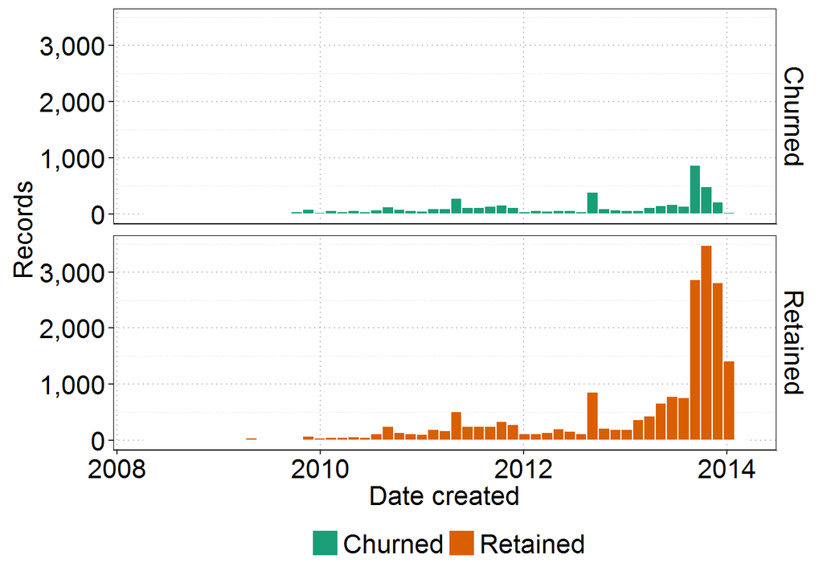

```r
field_plot(train, "created", "Date created", 50)
```

### First order date

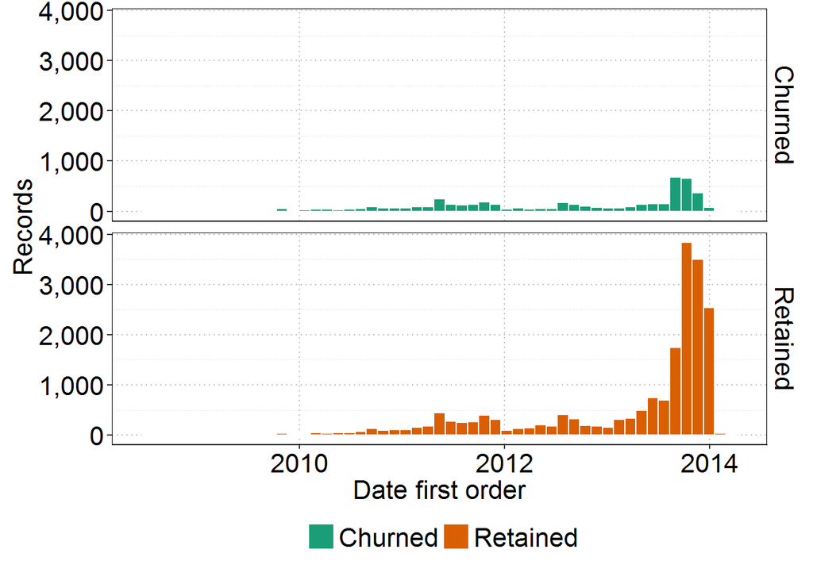

```r
field_plot(train, "firstorder", "Date first order", 50)
```

### Last order

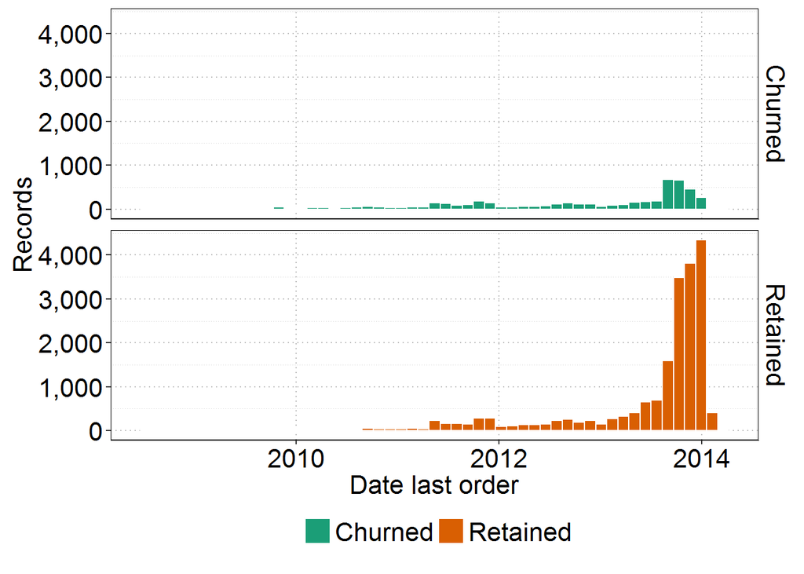

```r
field_plot(train, "lastorder", "Date last order", 50)
```

### Emails Sent

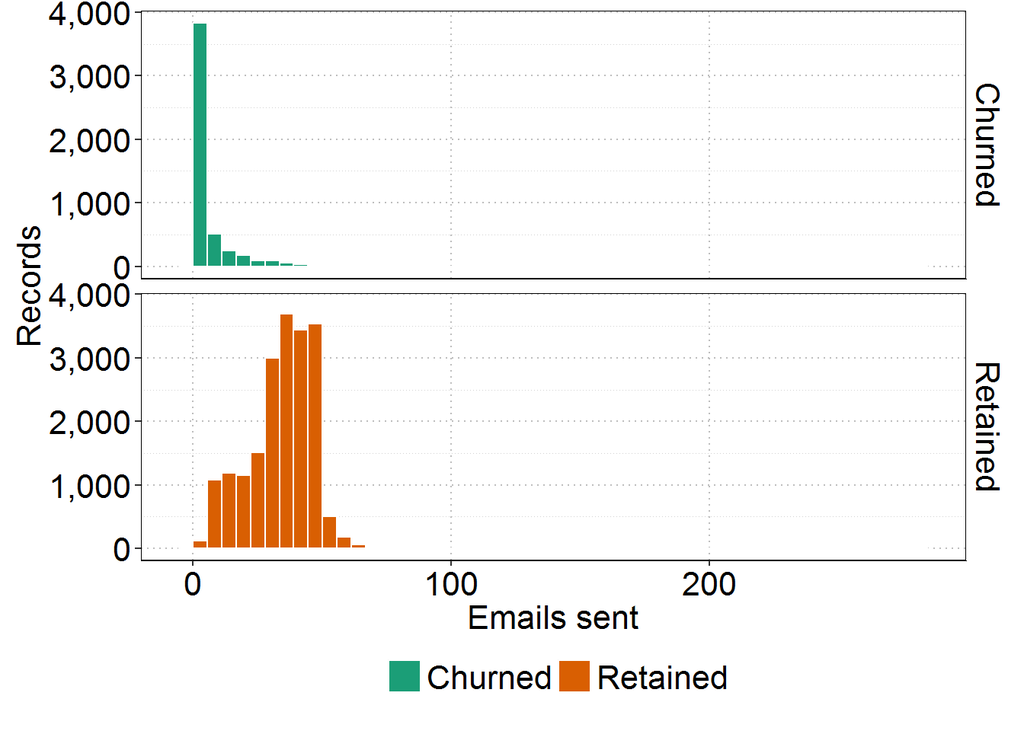

```r
field_plot(train, "esent", "Emails sent", 50)
```

### Emails opened (rate)

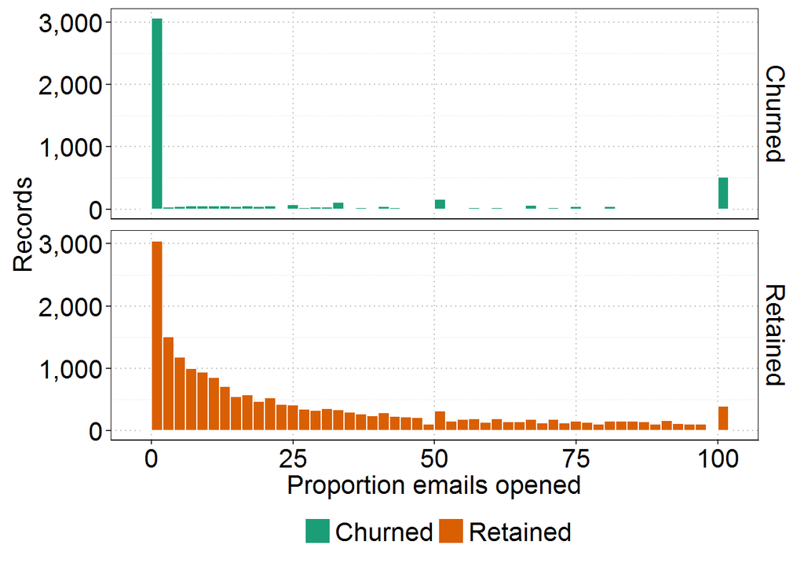

```r
field_plot(train, "eopenrate", "Proportion emails opened", 50)
```

### Emails clicked (rate)

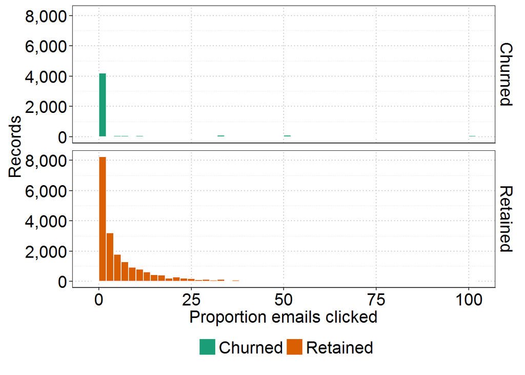

```r
field_plot(train, "eclickrate", "Proportion emails clicked", 50)
```

### Average Order

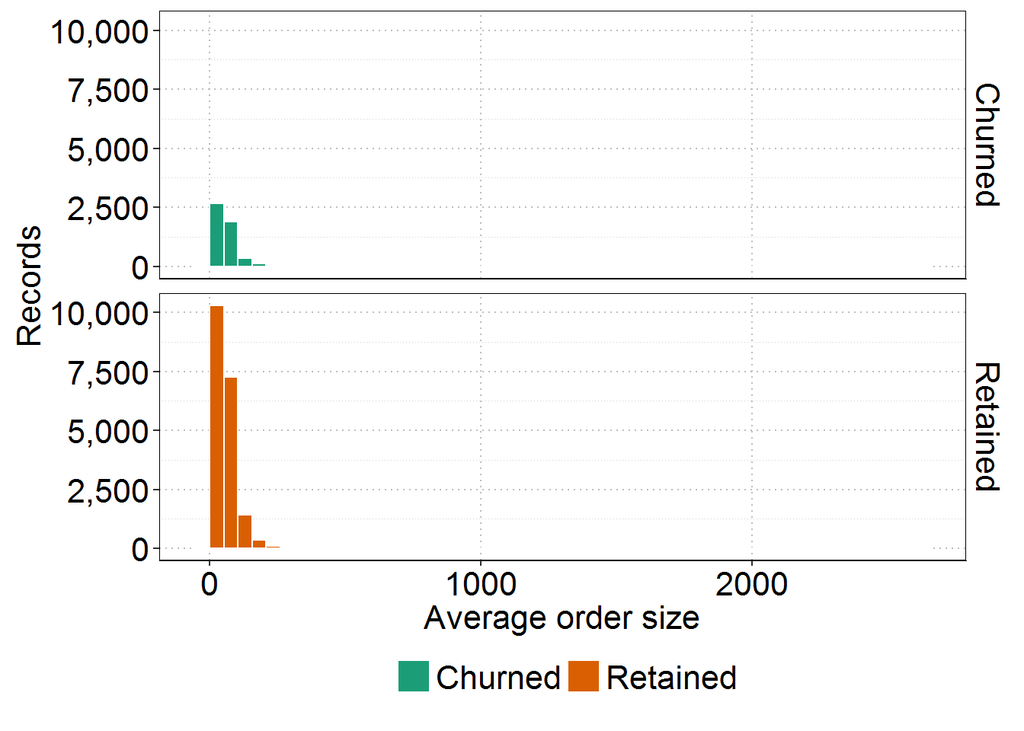

```r
field_plot(train, "avgorder", "Average order size", 50)
```

### Order frequency

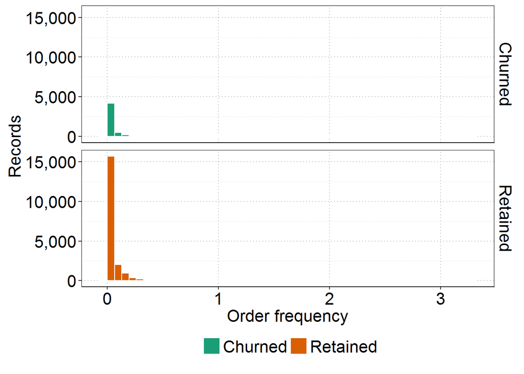

```r
field_plot(train, "ordfreq", "Order frequency", 50)
```

### Paperless communications

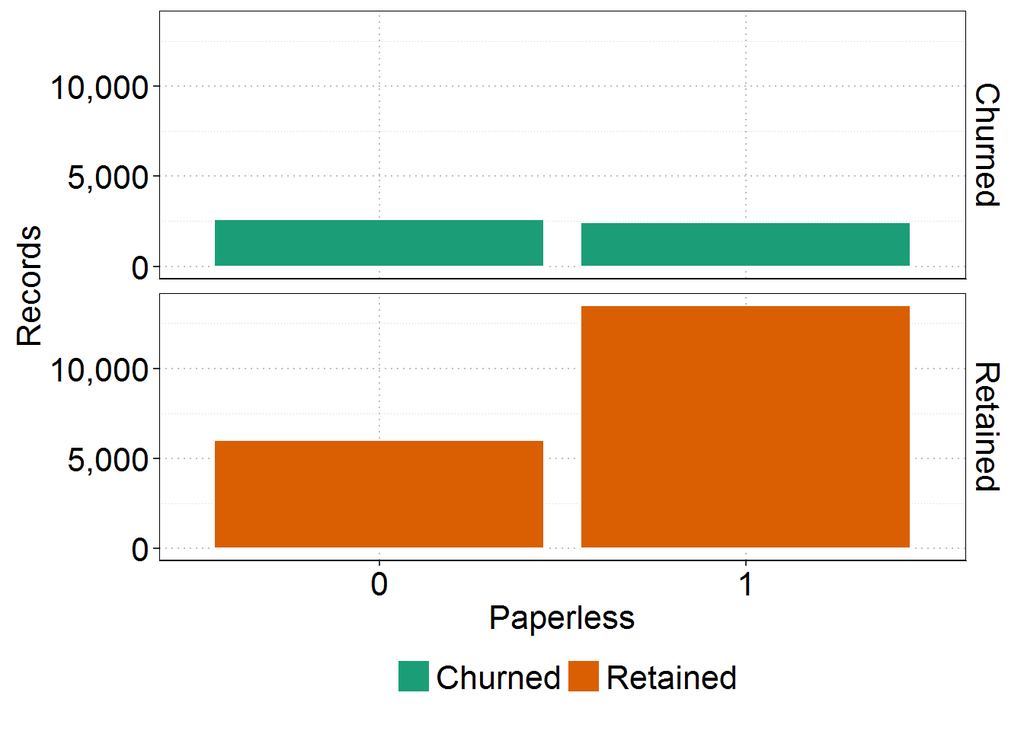

```r
field_plot_disc(train, "paperless", "Paperless")
```

### Automatic refill

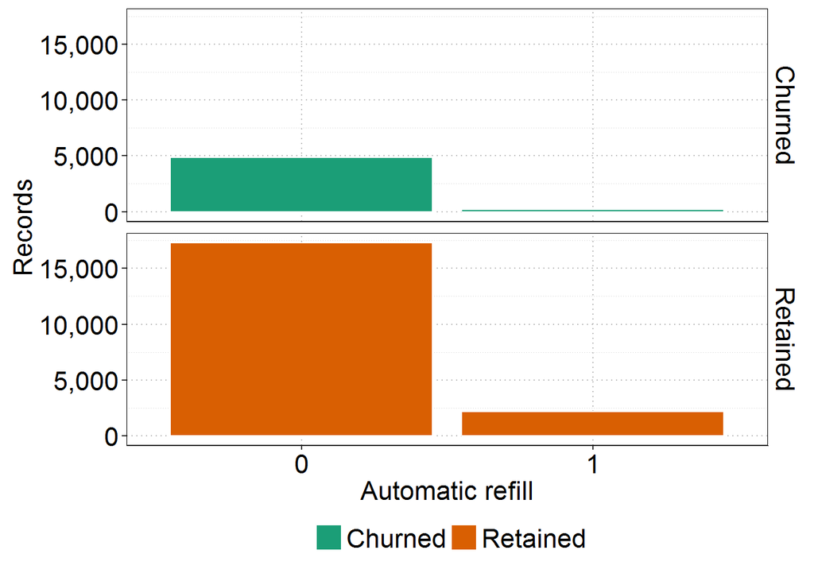

```r
field_plot_disc(train, "refill", "Automatic refill")
```

### Doorstep delivery

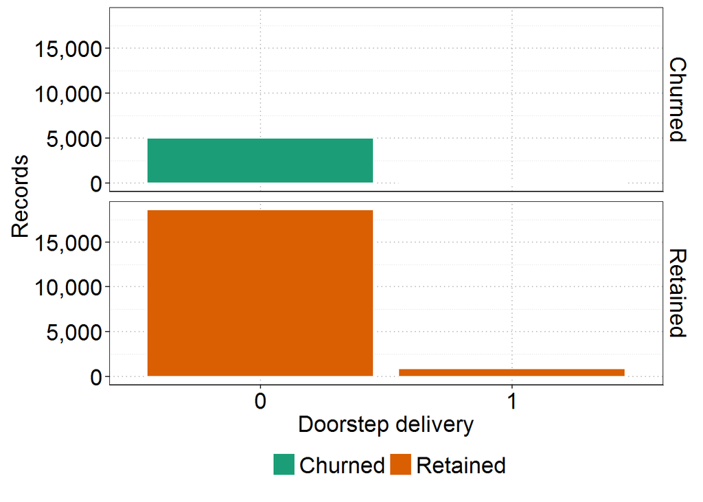

```r
field_plot_disc(train, "doorstep", "Doorstep delivery")
```

### Favourite delivery day

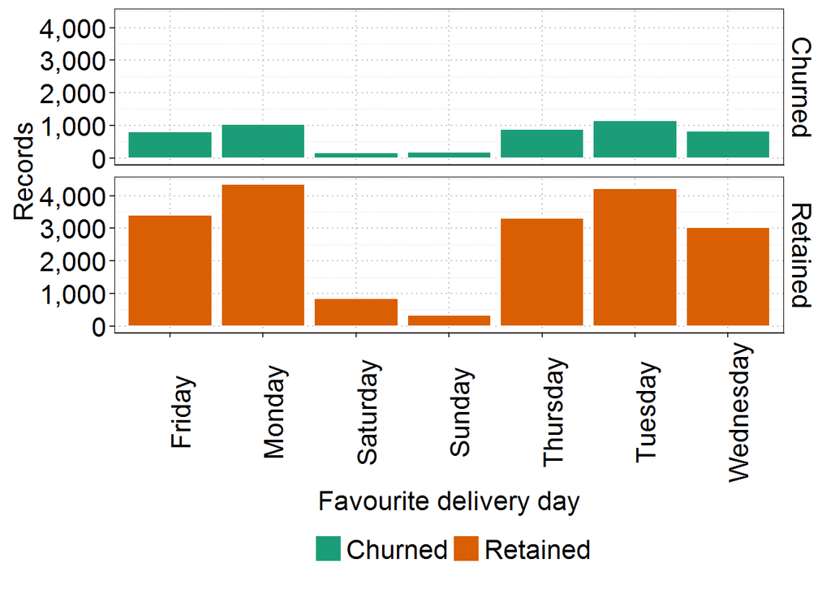

```r
field_plot_disc(train, "favday", "Favourite delivery day") +
  theme(axis.text.x = element_text(angle = 90))
```

### City

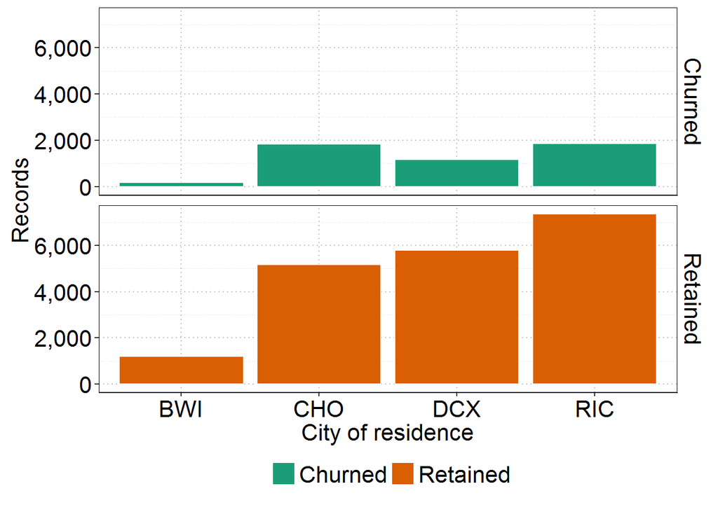

```r
field_plot_disc(train, "city", "City of residence")
```

## Exploration summary

# Section 2 - Logisitic regression

Stepwise logitstic regression was used to build a predicted model using the training data, beginning with a model that included all possible features.

```r
logit_all <- glm(retained ~ ., family = "binomial",
                 data = train %>% select(-custid))


logit_stepped <- step(logit_all, direction = "both", trace = 0)
```

The final model produced by the stepwise process is summarised below.

```r
logit_stepped %>% tidy() %>% kable(col.names = c("Term", "Estimate", "Std. Error",
                                                 "t-Stat.", "p-Value"),
                                   digits = 3,
                                   caption = "Table 1: Logistic Regression Coefficients")
```

Table 1: Logistic Regression Coefficients

| Term | Estimate | Std. Error | t-Stat. | p-Value |
| --- | --- | --- | --- | --- |
| (Intercept) | -4.109 | 1.480 | -2.776 | 0.005 |
| created | 0.000 | 0.000 | 5.755 | 0.000 |
| firstorder | 0.000 | 0.000 | 3.970 | 0.000 |
| lastorder | 0.000 | 0.000 | -12.571 | 0.000 |
| esent | 0.219 | 0.003 | 63.931 | 0.000 |
| eopenrate | 0.007 | 0.001 | 6.824 | 0.000 |
| eclickrate | 0.013 | 0.002 | 6.397 | 0.000 |
| avgorder | -0.002 | 0.001 | -3.534 | 0.000 |
| ordfreq | -0.578 | 0.234 | -2.470 | 0.014 |
| refill1 | 0.760 | 0.110 | 6.938 | 0.000 |
| doorstep1 | 0.917 | 0.170 | 5.391 | 0.000 |
| favdayMonday | -0.385 | 0.092 | -4.188 | 0.000 |
| favdaySaturday | -0.309 | 0.164 | -1.879 | 0.060 |
| favdaySunday | -1.114 | 0.263 | -4.237 | 0.000 |
| favdayThursday | -0.358 | 0.097 | -3.703 | 0.000 |
| favdayTuesday | -0.450 | 0.091 | -4.934 | 0.000 |
| favdayWednesday | -0.278 | 0.098 | -2.851 | 0.004 |
| cityCHO | -0.242 | 0.151 | -1.604 | 0.109 |
| cityDCX | -0.548 | 0.140 | -3.922 | 0.000 |
| cityRIC | -0.538 | 0.145 | -3.714 | 0.000 |

```r
logit_stepped %>% glance() %>% kable(col.names = c("Null deviance", "Deg. Freedom Null",
                                                   "Log-Likelihood", "AIC", "BIC",
                                                   "Deviance", "Deg. Freedom Residual"),
                                     digits = 3,
                                     caption = "Table 2: Logistic Regression Model fit")
```

Table 2: Logistic Regression Model fit

| Null deviance | Deg. Freedom Null | Log-Likelihood | AIC | BIC | Deviance | Deg. Freedom Residual |
| --- | --- | --- | --- | --- | --- | --- |
| 24901.91 | 24538 | -4074.09 | 8188.18 | 8350.341 | 8148.18 | 24519 |

This model was then used to make predictions on the test data. If the predicted probability of retention was greater than or equal to 0.5 then the customer was predicted to be retained, otherwise they were predicted to churn.

```r
logit_predict <- predict(logit_stepped, newdata = test, type = "response")
logit_predict[logit_predict >= .5] <- 1
logit_predict[logit_predict < .5] <- 0

logit_conf <- table(logit_predict, test$retained)
logit_accuracy <- sum(diag(logit_conf)) / sum(logit_conf)
```

Performing such predictions, the accuracy of the logistic regression model on the test data was found to be 94.4%. The confusion matrix for this model is displayed below.

```r
logit_conf %>% kable(caption = "Table 3: Logitistic regression out-of-sample confusion matrix. Rows represent the predicted labels and columns the actual values.")
```

Table 3: Logitistic regression out-of-sample confusion matrix. Rows represent the predicted labels and columns the actual values.

|  | 0 | 1 |
| --- | --- | --- |
| 0 | 1038 | 98 |
| 1 | 248 | 4835 |

# Section 3 - Random Forest

In a similar process, a random forest algorithm was applied to the training data in order to try to build a similar model. As with the logistic regression, all features were used to generate the model.

```r
rf <- randomForest(retained ~ .,
                   data = train %>% select(-custid),
                   ntree = 500,
                   importance = TRUE)
```

Due to the way that the random forest algorithm is implemented, using bootstrapped samples of both training samples *and* features, it is possible for the algorithm to generate an estimate of the out-of-sample performance after training the model on the training data. This estimate is presented below.

```r
rf$confusion %>% kable(col.names = c("0", "1", "Class Error"),
                       digits = 3,
                       caption = "Table 4: Random forest in-sample confusion matrix estimate. Rows represent the predicted labels and columns the actual values.")
```

|  | 0 | 1 | Class Error |
| --- | --- | --- | --- |
| 0 | 4503 | 530 | 0.105 |
| 1 | 199 | 19307 | 0.010 |

This seems to suggest that the accuracy of the model will be good on the test data. Predictions were made using the test data, and the true out-of-sample confusion matrix and accuracy are reported below.

```r
rf_predict <- predict(rf, newdata = test)

rf_conf <- table(rf_predict, test$retained)
rf_accuracy <- sum(diag(rf_conf)) / sum(rf_conf)

rf_conf %>% kable(caption = "Table 5: Random forest out-of-sample confusion matrix. Rows represent the predicted labels and columns the actual values.")
```

Table 5: Random forest out-of-sample confusion matrix. Rows represent the predicted labels and columns the actual values.

|  | 0 | 1 |
| --- | --- | --- |
| 0 | 74 | 6 |
| 1 | 1212 | 4927 |

This is a much worse performance than would have been expected based on the training estimate, providing an accuracy of just 80.4%.

# Section 4 - Comparison of models

When considering why the random forest algorithm performed much more poorly than logistic regression (which is not expected, typically random forest is a robust approach), it was discovered that the temporal aspects of the training and testing data are very different. The data date fields (`created`, `firstorder`, and `lastorder`) range from 2008-06-17 to 2014-01-20 in the *training* data whilst the *test* data date fields range from 1904-01-01 to 2018-01-21 (clearly there is potentially a data quality issue for the dates in the testing data).